# HW1_Mehta

Christine Mehta (cpm92)

# Section 1: Set up Workspace

```r
library(tidyverse)
library(ggplot2)
library(dplyr)
library(gapminder)
library(readr)

working_dir <- getwd()
data_dir <- file.path(working_dir, "Data")

## load data

democracy_csv <- read.csv("/Users/christinemehta/Dropbox/Cornell Academics/GOVT 6029/Assignment_1/Data/democracy.csv", stringsAsFactors = FALSE, na.strings = ".")
View(democracy_csv)
```

# Section 2: Initial Data Exploration

```r
summary(democracy_csv)
```

[output not shown]

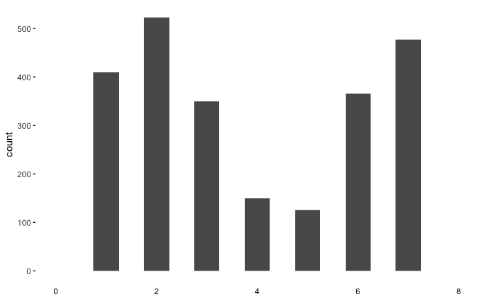

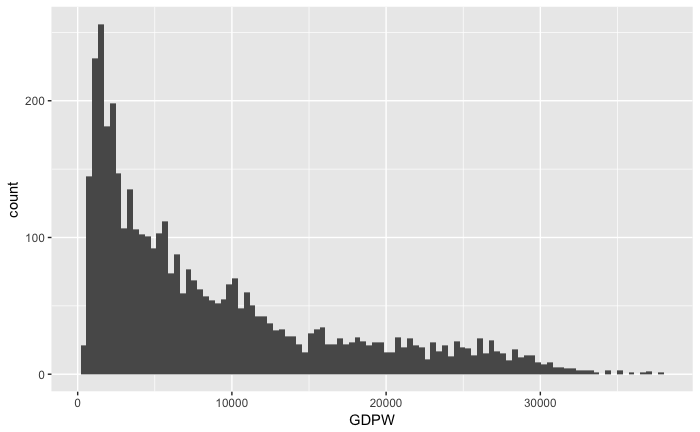

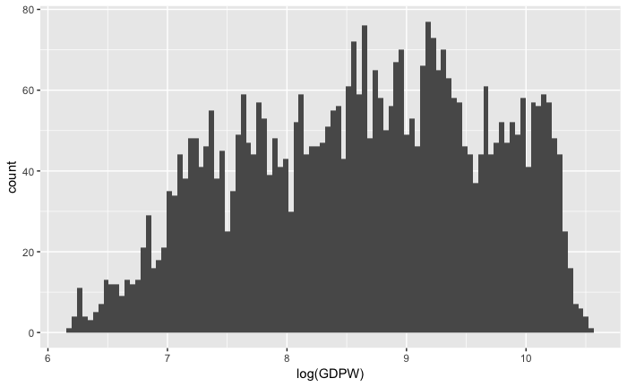

# Section 3: Explore Relationships

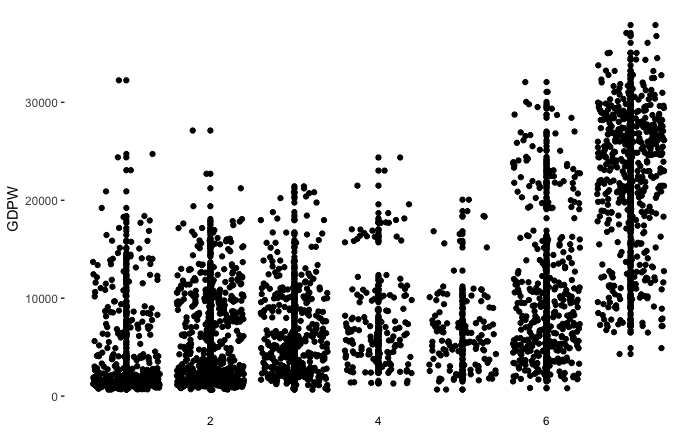

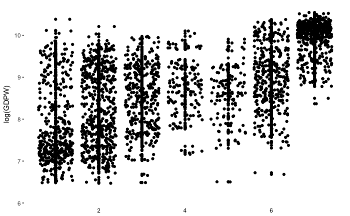

Description: The relationship between logged GDP per Cap and poitical liberties is distinctly more linear in this plot.

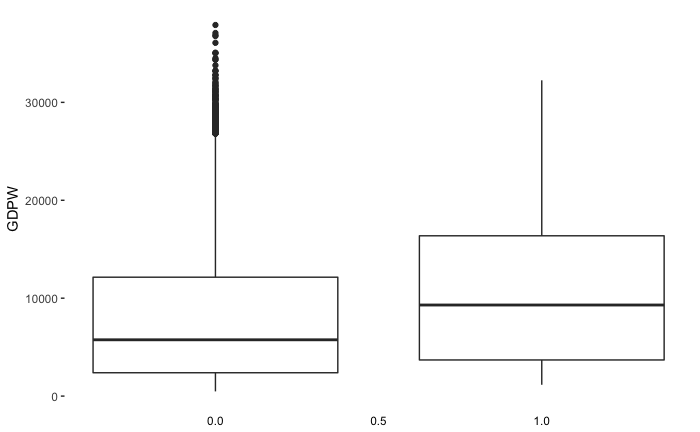

# Section 4: Tranform data and analyse

```r
summary(cathcountry)
```

```
    COUNTRY         CTYNAME             REGION               YEAR         BRITCOL             CATH
 Min.   :  6.00   Length:1643        Length:1643        Min.   :1951   Min.   :0.00000   Min.   :43.00
 1st Qu.: 57.00   Class :character   Class :character   1st Qu.:1963   1st Qu.:0.00000   1st Qu.:75.00
 Median : 70.00   Mode  :character   Mode  :character   Median :1973   Median :0.00000   Median :89.00
 Mean   : 76.51                                         Mean   :1972   Mean   :0.09191   Mean   :81.05
 3rd Qu.:108.00                                         3rd Qu.:1982   3rd Qu.:0.00000   3rd Qu.:92.60
 Max.   :128.00                                         Max.   :1990   Max.   :1.00000   Max.   :99.00

     CIVLIB           EDT             ELF60            GDPW           MOSLEM             NEWC
 Min.   :1.000   Min.   : 0.540   Min.   :0.010   Min.   :  590   Min.   : 0.0000   Min.   :0.0000
 1st Qu.:2.000   1st Qu.: 3.435   1st Qu.:0.070   1st Qu.: 4564   1st Qu.: 0.0000   1st Qu.:0.0000
 Median :3.000   Median : 5.290   Median :0.170   Median : 8165   Median : 0.0000   Median :0.0000
 Mean   :3.588   Mean   : 5.342   Mean   :0.296   Mean   :10295   Mean   : 0.9449   Mean   :0.1917
 3rd Qu.:5.000   3rd Qu.: 6.876   3rd Qu.:0.530   3rd Qu.:13889   3rd Qu.: 0.1000   3rd Qu.:0.0000
 Max.   :7.000   Max.   :12.680   Max.   :0.900   Max.   :37903   Max.   :12.0000   Max.   :1.0000
 NA's   :764     NA's   :515      NA's   :146
      OIL             POLLIB           REG             STRA
 Min.   :0.0000   Min.   :1.000   Min.   :0.000   Min.   :0.0000
 1st Qu.:0.0000   1st Qu.:2.000   1st Qu.:0.000   1st Qu.:0.0000
 Median :0.0000   Median :4.000   Median :1.000   Median :0.0000
 Mean   :0.1096   Mean   :4.344   Mean   :0.518   Mean   :0.6659
 3rd Qu.:0.0000   3rd Qu.:7.000   3rd Qu.:1.000   3rd Qu.:1.0000
 Max.   :1.0000   Max.   :7.000   Max.   :1.000   Max.   :5.0000
                  NA's   :764
```

Answer: The mean GDP per capita for countries with at least 40 percent Catholics is $10,295. The mean GDP per capita for all countries is $8,877. Majority Catholic countries have, on average, a higher GDP per capita than the same measure for all countries.

```r
summary(ELF60_NA)
```

```
    COUNTRY         CTYNAME             REGION               YEAR         BRITCOL            CATH
 Min.   :  8.00   Length:542         Length:542         Min.   :1951   Min.   :0.0000   Min.   : 0.00
 1st Qu.: 75.00   Class :character   Class :character   1st Qu.:1973   1st Qu.:0.0000   1st Qu.: 0.00
 Median : 96.00   Mode  :character   Mode  :character   Median :1980   Median :0.0000   Median :10.80
 Mean   : 87.05                                         Mean   :1978   Mean   :0.3063   Mean   :27.71
 3rd Qu.:119.00                                         3rd Qu.:1985   3rd Qu.:1.0000   3rd Qu.:62.00
 Max.   :135.00                                         Max.   :1990   Max.   :1.0000   Max.   :95.00

     CIVLIB           EDT             ELF60          GDPW           MOSLEM           NEWC
 Min.   :1.000   Min.   : 0.240   Min.   : NA   Min.   :  830   Min.   : 0.00   Min.   :0.0000
 1st Qu.:4.000   1st Qu.: 2.895   1st Qu.: NA   1st Qu.: 3524   1st Qu.: 0.00   1st Qu.:0.0000
 Median :6.000   Median : 5.650   Median : NA   Median : 6293   Median : 7.50   Median :0.0000
 Mean   :4.962   Mean   : 5.597   Mean   :NaN   Mean   : 7767   Mean   :24.43   Mean   :0.4631
 3rd Qu.:6.000   3rd Qu.: 7.965   3rd Qu.: NA   3rd Qu.:10888   3rd Qu.:19.60   3rd Qu.:1.0000
 Max.   :7.000   Max.   :11.270   Max.   : NA   Max.   :32253   Max.   :99.70   Max.   :1.0000
 NA's   :121     NA's   :291      NA's   :542
      OIL             POLLIB           REG             STRA
 Min.   :0.0000   Min.   :1.000   Min.   :0.000   Min.   :0.0000
 1st Qu.:0.0000   1st Qu.:2.000   1st Qu.:0.000   1st Qu.:0.0000
 Median :0.0000   Median :2.000   Median :0.000   Median :0.0000
 Mean   :0.1273   Mean   :2.931   Mean   :0.155   Mean   :0.2325
 3rd Qu.:0.0000   3rd Qu.:4.000   3rd Qu.:0.000   3rd Qu.:0.0000
 Max.   :1.0000   Max.   :7.000   Max.   :1.000   Max.   :1.0000
                  NA's   :121
```

Answer: Countries with greater than 60 percent ethnolinguistic fractionalization have a mean GDP per capita of $3,591. Countries with less than 60 percent ethnolinguistic fractionalization have a mean GDP per capita of $11,804. Countries with missing ethnolinguistic fractionalization data have a mean GDP per capita of $7,767.

```r
summary(countries_1985)
```

```
    COUNTRY        CTYNAME             REGION               YEAR         BRITCOL            CATH
 Min.   :  1.0   Length:135         Length:135         Min.   :1985   Min.   :0.0000   Min.   : 0.00
 1st Qu.: 34.5   Class :character   Class :character   1st Qu.:1985   1st Qu.:0.0000   1st Qu.: 0.00
 Median : 68.0   Mode  :character   Mode  :character   Median :1985   Median :0.0000   Median :18.80
 Mean   : 68.0                                         Mean   :1985   Mean   :0.2741   Mean   :33.95
 3rd Qu.:101.5                                         3rd Qu.:1985   3rd Qu.:1.0000   3rd Qu.:75.00
 Max.   :135.0                                         Max.   :1985   Max.   :1.0000   Max.   :99.00

     CIVLIB           EDT             ELF60             GDPW           MOSLEM           NEWC
 Min.   :1.000   Min.   : 0.625   Min.   :0.0000   Min.   :  705   Min.   : 0.00   Min.   :0.0000
 1st Qu.:2.000   1st Qu.: 3.520   1st Qu.:0.1325   1st Qu.: 2681   1st Qu.: 0.00   1st Qu.:0.0000
 Median :5.000   Median : 5.625   Median :0.4250   Median : 6878   Median : 1.00   Median :1.0000
 Mean   :4.237   Mean   : 5.960   Mean   :0.4215   Mean   : 9847   Mean   :20.62   Mean   :0.5407
 3rd Qu.:6.000   3rd Qu.: 7.810   3rd Qu.:0.6975   3rd Qu.:14401   3rd Qu.:17.95   3rd Qu.:1.0000
 Max.   :7.000   Max.   :12.810   Max.   :0.9300   Max.   :33783   Max.   :99.90   Max.   :1.0000
                 NA's   :22       NA's   :29
      OIL             POLLIB           REG              STRA
 Min.   :0.0000   Min.   :1.000   Min.   :0.0000   Min.   :0.0000
 1st Qu.:0.0000   1st Qu.:2.000   1st Qu.:0.0000   1st Qu.:0.0000
 Median :0.0000   Median :3.000   Median :0.0000   Median :0.0000
 Mean   :0.0963   Mean   :3.926   Mean   :0.3778   Mean   :0.4444
 3rd Qu.:0.0000   3rd Qu.:6.000   3rd Qu.:1.0000   3rd Qu.:1.0000
 Max.   :1.0000   Max.   :7.000   Max.   :1.0000   Max.   :5.0000
```

Answer: The median average years of education in 1985 ONLY for all countries is 5.625 years.

| COUNTRY | CTYNAME | REGION | YEAR | BRITCOL | CATH | CIVLIB | EDT | ELF60 | GDPW | MOSLEM | NEWC | OIL | POLLIB | REG | STRA |
| --- | --- | --- | --- | --- | --- | --- | --- | --- | --- | --- | --- | --- | --- | --- | --- |
| 77 | Venezuela | South America | 1985 | 0 | 95 | 2 | 5.625 | 0.11 | 18362 | 0 | 0 | 1 | 7 | 1 | 1 |

```r
countries_1985 %>%
  filter(REG == "1") %>%
  summary()
```

```
    COUNTRY         CTYNAME             REGION               YEAR         BRITCOL            CATH
 Min.   : 29.00   Length:51          Length:51          Min.   :1985   Min.   :0.0000   Min.   : 0.0
 1st Qu.: 64.50   Class :character   Class :character   1st Qu.:1985   1st Qu.:0.0000   1st Qu.:13.9
 Median : 99.00   Mode  :character   Mode  :character   Median :1985   Median :0.0000   Median :47.6
 Mean   : 90.57                                         Mean   :1985   Mean   :0.2549   Mean   :51.1
 3rd Qu.:116.50                                         3rd Qu.:1985   3rd Qu.:0.5000   3rd Qu.:91.4
 Max.   :134.00                                         Max.   :1985   Max.   :1.0000   Max.   :99.0

     CIVLIB           EDT             ELF60             GDPW           MOSLEM            NEWC
 Min.   :1.000   Min.   : 1.740   Min.   :0.0100   Min.   : 2719   Min.   : 0.000   Min.   :0.0000
 1st Qu.:1.000   1st Qu.: 6.150   1st Qu.:0.0700   1st Qu.: 7282   1st Qu.: 0.000   1st Qu.:0.0000
 Median :2.000   Median : 7.805   Median :0.1750   Median :16270   Median : 0.000   Median :0.0000
 Mean   :2.078   Mean   : 8.074   Mean   :0.2626   Mean   :16784   Mean   : 3.165   Mean   :0.2549
 3rd Qu.:3.000   3rd Qu.:10.250   3rd Qu.:0.4350   3rd Qu.:26272   3rd Qu.: 0.000   3rd Qu.:0.5000
 Max.   :5.000   Max.   :12.810   Max.   :0.8900   Max.   :33783   Max.   :99.200   Max.   :1.0000
                 NA's   :6        NA's   :5
      OIL              POLLIB           REG         STRA
 Min.   :0.00000   Min.   :3.000   Min.   :1   Min.   :0.0000
 1st Qu.:0.00000   1st Qu.:6.000   1st Qu.:1   1st Qu.:0.0000
 Median :0.00000   Median :7.000   Median :1   Median :0.0000
 Mean   :0.05882   Mean   :6.412   Mean   :1   Mean   :0.5686
 3rd Qu.:0.00000   3rd Qu.:7.000   3rd Qu.:1   3rd Qu.:1.0000
 Max.   :1.00000   Max.   :7.000   Max.   :1   Max.   :5.0000
```

Answer: The median of the average years of education in 1985 for democracies was 7.805 years.

| COUNTRY | CTYNAME | REGION | YEAR | BRITCOL | CATH | CIVLIB | EDT | ELF60 | GDPW | MOSLEM | NEWC | OIL | POLLIB | REG | STRA |
| --- | --- | --- | --- | --- | --- | --- | --- | --- | --- | --- | --- | --- | --- | --- | --- |
| 29 | Mauritius | Africa | 1985 | 1 | 25.7 | 2 | 7.805 | 0.58 | 7474 | 12.9 | 1 | 0 | 6 | 1 | 0 |
| 74 | Peru | South America | 1985 | 0 | 92.5 | 3 | 7.250 | 0.59 | 8141 | 0.0 | 0 | 0 | 6 | 1 | 3 |
| 101 | Austria | Europe | 1985 | 0 | 84.3 | 1 | 7.280 | 0.13 | 23837 | 6.0 | 0 | 0 | 7 | 1 | 1 |
| 107 | France | Europe | 1985 | 0 | 76.4 | 2 | 7.910 | 0.26 | 27064 | 0.0 | 0 | 0 | 7 | 1 | 0 |
| 110 | Greece | Europe | 1985 | 0 | 98.0 | 2 | 7.485 | 0.10 | 16270 | 1.5 | 0 | 0 | 6 | 1 | 2 |
| 114 | Italy | Europe | 1985 | 0 | 99.0 | 1 | 7.390 | 0.04 | 27189 | 0.0 | 0 | 0 | 7 | 1 | 1 |
| 122 | Spain | Europe | 1985 | 0 | 97.0 | 2 | 7.195 | 0.44 | 21169 | 0.0 | 0 | 0 | 7 | 1 | 1 |

Answer: The closest single democracy in 1985 to median average years of education was Mauritius. The closest 7 democracies (between 7 and 8 years of education) were Peru, Austria, France, Greece, Italy and Spain.

```r
democracy_csv %>%
  filter(NEWC == "1") %>%
  summary()
```

```
    COUNTRY         CTYNAME             REGION               YEAR         BRITCOL            CATH
 Min.   :  1.00   Length:1882        Length:1882        Min.   :1951   Min.   :0.0000   Min.   : 0.00
 1st Qu.: 21.00   Class :character   Class :character   1st Qu.:1969   1st Qu.:0.0000   1st Qu.: 0.00
 Median : 40.00   Mode  :character   Mode  :character   Median :1977   Median :0.0000   Median : 5.30
 Mean   : 49.19                                         Mean   :1976   Mean   :0.4729   Mean   :18.22
 3rd Qu.: 84.00                                         3rd Qu.:1984   3rd Qu.:1.0000   3rd Qu.:26.20
 Max.   :135.00                                         Max.   :1990   Max.   :1.0000   Max.   :97.30

     CIVLIB          EDT             ELF60            GDPW           MOSLEM           NEWC
 Min.   :1.00   Min.   : 0.030   Min.   :0.040   Min.   :  480   Min.   : 0.00   Min.   :1
 1st Qu.:4.00   1st Qu.: 1.390   1st Qu.:0.420   1st Qu.: 1546   1st Qu.: 0.50   1st Qu.:1
 Median :5.00   Median : 2.630   Median :0.650   Median : 2739   Median :14.40   Median :1
 Mean   :4.77   Mean   : 3.397   Mean   :0.556   Mean   : 4732   Mean   :33.97   Mean   :1
 3rd Qu.:6.00   3rd Qu.: 4.933   3rd Qu.:0.750   3rd Qu.: 5728   3rd Qu.:85.00   3rd Qu.:1
 Max.   :7.00   Max.   :11.190   Max.   :0.930   Max.   :32071   Max.   :99.90   Max.   :1
 NA's   :617    NA's   :515      NA's   :251
      OIL            POLLIB           REG              STRA
 Min.   :0.000   Min.   :1.000   Min.   :0.0000   Min.   :0.000
 1st Qu.:0.000   1st Qu.:2.000   1st Qu.:0.0000   1st Qu.:0.000
 Median :0.000   Median :3.000   Median :0.0000   Median :0.000
 Mean   :0.119   Mean   :3.134   Mean   :0.2024   Mean   :0.204
 3rd Qu.:0.000   3rd Qu.:5.000   3rd Qu.:0.0000   3rd Qu.:0.000
 Max.   :1.000   Max.   :7.000   Max.   :1.0000   Max.   :3.000
                 NA's   :617
```

Answer: For new countries (created after 1945) the 25th and 75th percentiles of ethnolinguistic fractionalization was 42 and 75 percent respectively.

```r
democracy_csv %>%
  filter(NEWC == "0") %>%
  summary()
```

```
    COUNTRY         CTYNAME             REGION               YEAR         BRITCOL            CATH
 Min.   : 14.00   Length:2244        Length:2244        Min.   :1951   Min.   :0.0000   Min.   : 0.00
 1st Qu.: 65.00   Class :character   Class :character   1st Qu.:1962   1st Qu.:0.0000   1st Qu.: 0.90
 Median : 87.00   Mode  :character   Mode  :character   Median :1972   Median :0.0000   Median :75.00
 Mean   : 87.79                                         Mean   :1971   Mean   :0.0508   Mean   :53.12
 3rd Qu.:114.00                                         3rd Qu.:1981   3rd Qu.:0.0000   3rd Qu.:92.20
 Max.   :131.00                                         Max.   :1990   Max.   :1.0000   Max.   :99.00

     CIVLIB           EDT             ELF60             GDPW           MOSLEM            NEWC
 Min.   :1.000   Min.   : 0.040   Min.   :0.0000   Min.   :  505   Min.   : 0.000   Min.   :0
 1st Qu.:1.000   1st Qu.: 3.945   1st Qu.:0.0600   1st Qu.: 5556   1st Qu.: 0.000   1st Qu.:0
 Median :3.000   Median : 5.925   Median :0.1600   Median :10102   Median : 0.000   Median :0
 Mean   :3.303   Mean   : 6.152   Mean   :0.2688   Mean   :12353   Mean   : 7.796   Mean   :0
 3rd Qu.:5.000   3rd Qu.: 8.670   3rd Qu.:0.4400   3rd Qu.:18404   3rd Qu.: 1.400   3rd Qu.:0
 Max.   :7.000   Max.   :12.810   Max.   :0.8800   Max.   :37903   Max.   :99.200   Max.   :0
 NA's   :1110    NA's   :711      NA's   :291
      OIL              POLLIB           REG              STRA
 Min.   :0.00000   Min.   :1.000   Min.   :0.0000   Min.   :0.0000
 1st Qu.:0.00000   1st Qu.:2.000   1st Qu.:0.0000   1st Qu.:0.0000
 Median :0.00000   Median :6.000   Median :1.0000   Median :0.0000
 Mean   :0.08422   Mean   :4.668   Mean   :0.5633   Mean   :0.5187
 3rd Qu.:0.00000   3rd Qu.:7.000   3rd Qu.:1.0000   3rd Qu.:1.0000
 Max.   :1.00000   Max.   :7.000   Max.   :1.0000   Max.   :5.0000
                   NA's   :1110
```

Answer: For old countries (created prior to 1945), the level to ethnolinguistic fractionalization at the 25th and 75th percentiles was 6 and 44 percent respectively.